# Village comparisons

### Background

To help get a sense of the variation of contexts between sites, I have pulled together the locations of the villages across the different sites (exc. Tanzania and Malawi), and have generated descriptions using the following secondary spatial datasets:

- *Country*
- *Terrestrial, freshwater and marine ecoregions* (from TNC http://maps.tnc.org/gis_data.html)
- *Land cover type* in 2013 (from FAO http://www.fao.org/geonetwork/srv/en/main.home?uuid=ba4526fd-cdbf-4028-a1bd-5a559c4bff38)
- *Population* of subnational region in 2013 (from OPHI https://ophi.org.uk/2013-mpi-data-tables/; 2015 for Peru)
- *Poverty:* national and subnational regional global multi-dimensional poverty indices in 2013 (from OPHI https://ophi.org.uk/2013-mpi-data-tables/; 2015 for Peru)
- *Market access:* travel time to nearest city of 50k people in 2015 (from Weiss et al. https://map.ox.ac.uk/research-project/accessibility_to_cities/)
- *Human pressure on environment:* Human Footprint Index in 2009 (from Venter et al. https://sedac.ciesin.columbia.edu/data/set/wildareas-v3-2009-human-footprint)
- *Distance from protected area:* from 2019 (derived from IUCN/UNEP https://www.protectedplanet.net/)

We are waiting on spatial information for Tanzania (PIMA, 42 villages) and Malawi (ASSETS, 6 villages). The locations for Colombia are also not quite right at the moment, but sufficient for this exercise.

Note that for the actual analysis we need to confirm the nature of the spatial boundaries we have for each site - do they relate to village boundaries, resource areas? Also many of the spatial products are quite general, so the following indicators should be considered very rough.

### Site locations

Our sites are located as follows:

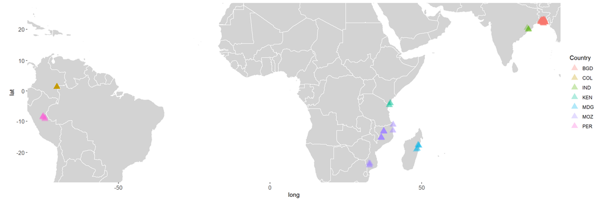

We have a total of 183 villages (or similar). The number in each country is as follows (not including Tanzania and Malawi):

```
## BGD COL IND KEN MDG MOZ PER
##  63  11   4   4   7  37   9
```

### Ecoregions and land cover

Our villages span the followng broad ecoregions:

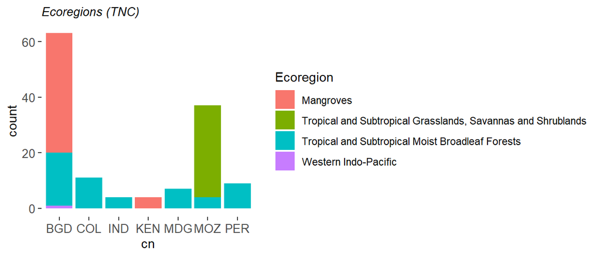

And the following rough land cover types (but categorisations are not great for some systems!):

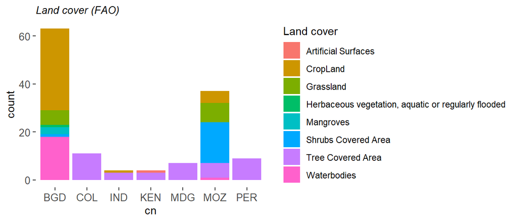

### Population and poverty

The populations in the ‘sub-national’ regions (usually one administartive division below national) of our sites according to OPHI:

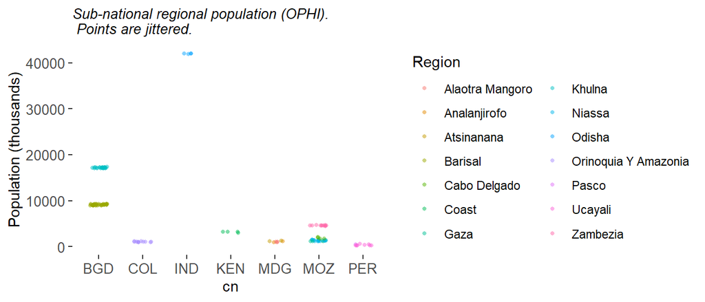

Global multi-dimensional poverty index at the national and sub-national levels are (higher is more poverty):

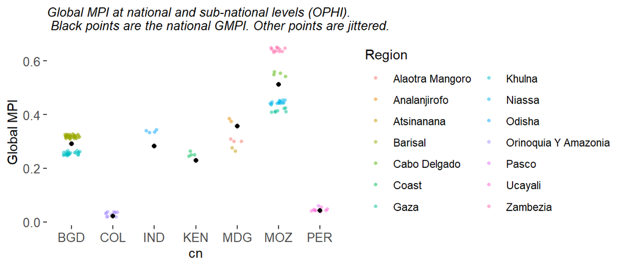

### Market access

Travel time to the nearest city (as a proxy for market access) is:

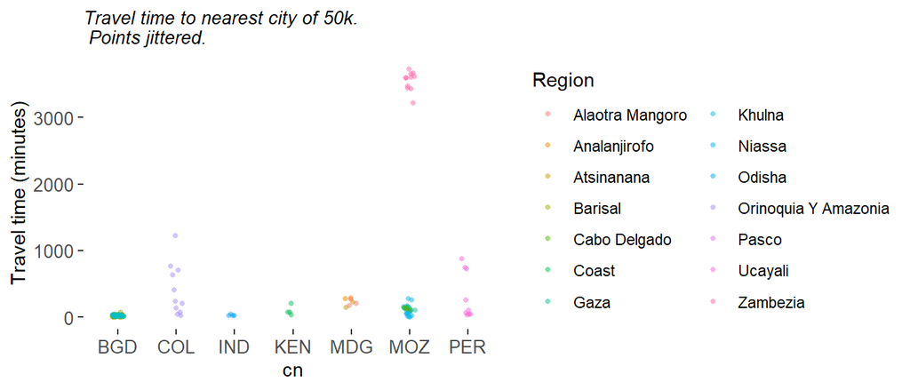

### Ecological condition

Human footprint index (as a proxy for human pressure on the environment; higher is more pressure) is:

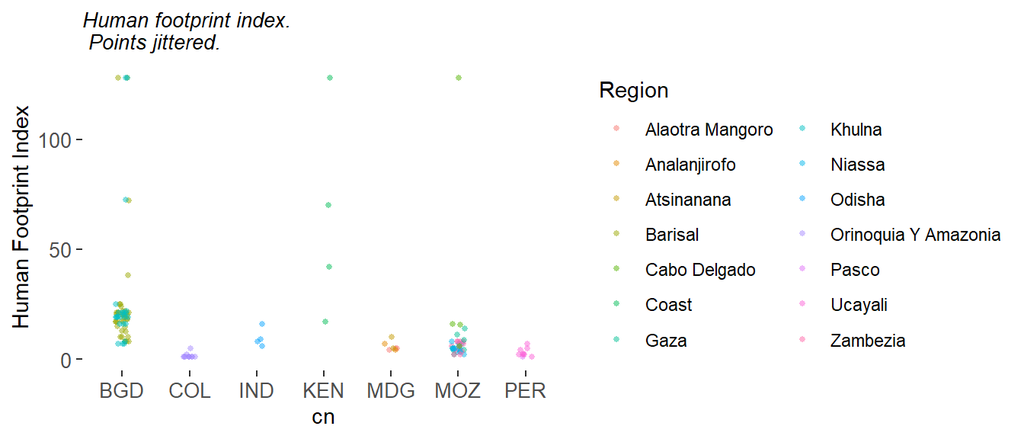

### Protected areas

And distance to the nearest protected area is as follows (the underlying dataset is not great though!):

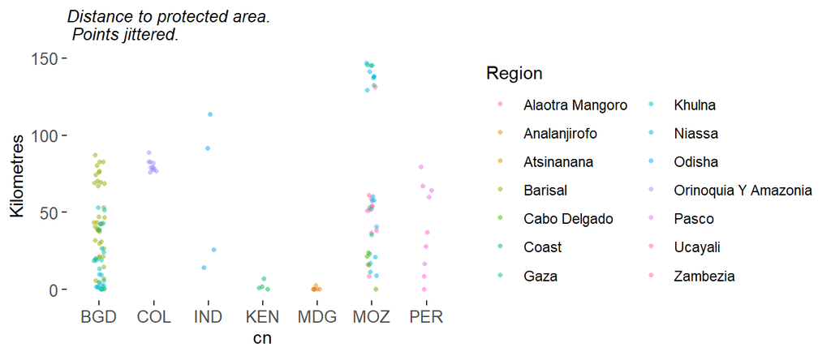